# Literature review

Marie Auger-Méthé

2026-04-24

# Goals

1. Identify the proportion of recent papers that use habitat selection analysis to inform conservation and management
2. Identify the proportion of recent papers that include characteristics of individual, with a focus on health and fitness proxies.

# General set up

## Load packages

```r
library(tidyverse)
library(readxl)
library(here)
library(ggpubr) # To put plots side-by-side
library(grafify) # For color-blind friendly palette
```

# Search and screening processes

A Web of Science search was conducted using the following search term in the Topic field: (resource selection function OR step*selection function OR habitat selection analys*) AND (telemetry OR tag* OR collar* OR GPS OR Global Positioning System). We used the Web of Science platform to search all databases available from the library of the University of British Columbia, Canada, on April 28, 2025. These databases (with their Web of Science labels in brackets) were: Biological Abstracts (BIOABS), BIOSIS Citation Index (BCI), BIOSIS Previews (BIOSIS), Current Contents Connect (CCC), Data Citation Index (DRCI), Derwent Innovations Index (DIIDW), FSTA - the food science resource (FSTA), Grants Index (GRANTS), KCI-Korean Journal Database (KJD), MEDLINE (MEDLINE), Policy Citation Index (PCI), Preprint Citation Index (PPRN), ProQuest Dissertation & Theses Citation Index (PQDT), Research Commons (RC), SciELO Citation Index (SCIELO), Web of Science Core Collection (WOS), and Zoological Record (ZOOREC). We restricted the search to documents published between April 29, 2024 and April 28, 2025 using the Publication Date fields.

Devin A. Lyons (DAL) screened all titles and removed duplicates and patents. DAL and Marie Auger-Méthé (MAM) screened the abstracts. MAM screened the full texts that remained after previous exclusions and extracted information from the articles.

# Visualizing the results

## Loading the literature review data

```r
review <- read_excel(path=file.path(here("Data/0_Review"),
                                  "Literature_review.xlsx"))
head(review)
```

```
## # A tibble: 6 × 23
##   Authors         `Article Title` `Source Title` Volume Issue `Publication Year`
##   <chr>           <chr>           <chr>          <chr>  <chr> <chr>
## 1 Donini, Valeri… Can camera tra… LANDSCAPE ECO… 40     2     2025
## 2 Crews, Storm; … Hierarchy in S… ECOLOGY AND E… 15     3     2025
## 3 Singh, Navinde… Linear infrast… The Science o… 955    <NA>  2024
## 4 Hysen, Logan; … Variability in… ECOLOGICAL MO… 501    <NA>  2025
## 5 Parracciani, C… Seasonal and a… ECOLOGY AND E… 14     10    2024
## 6 Pereira, Alexi… Flexible migra… JOURNAL OF WI… 88     8     2024
## # ℹ 17 more variables: Abstract <chr>, TitleExclude <chr>,
## #   AbstractExclude <chr>, FullTextExclude <chr>, AccountForIndividuals <chr>,
## #   IncludeCharacteristicsOfFitnessHealth <chr>,
## #   FitnessHealthCharacteristic <chr>,
## #   IncludeCharacteristicsOfFitnessHealthSpecific <chr>,
## #   IncludeOtherCharacteristic <chr>, OtherCharacteristic <chr>,
## #   MethodCharacteristic <chr>, CommentMethodCharacteristic <chr>, …
```

We want to extract only the papers that were kept after screening.

```r
review <- review %>%
  filter(TitleExclude == "N"  & AbstractExclude == "N" & FullTextExclude == "N")
head(review)
```

```
## # A tibble: 6 × 23
##   Authors         `Article Title` `Source Title` Volume Issue `Publication Year`
##   <chr>           <chr>           <chr>          <chr>  <chr> <chr>
## 1 Donini, Valeri… Can camera tra… LANDSCAPE ECO… 40     2     2025
## 2 Crews, Storm; … Hierarchy in S… ECOLOGY AND E… 15     3     2025
## 3 Singh, Navinde… Linear infrast… The Science o… 955    <NA>  2024
## 4 Hysen, Logan; … Variability in… ECOLOGICAL MO… 501    <NA>  2025
## 5 Parracciani, C… Seasonal and a… ECOLOGY AND E… 14     10    2024
## 6 Pereira, Alexi… Flexible migra… JOURNAL OF WI… 88     8     2024
## # ℹ 17 more variables: Abstract <chr>, TitleExclude <chr>,
## #   AbstractExclude <chr>, FullTextExclude <chr>, AccountForIndividuals <chr>,
## #   IncludeCharacteristicsOfFitnessHealth <chr>,
## #   FitnessHealthCharacteristic <chr>,
## #   IncludeCharacteristicsOfFitnessHealthSpecific <chr>,
## #   IncludeOtherCharacteristic <chr>, OtherCharacteristic <chr>,
## #   MethodCharacteristic <chr>, CommentMethodCharacteristic <chr>, …
```

Look at number of papers kept.

```r
n <- nrow(review)
n
```

```
## [1] 72
```

## Use for conservation and management inference

Look at the potential answers to the question: Is conservation or management inference made based on the results?

```r
review %>% select("ManagementConservationInference") %>% unique()
```

```
## # A tibble: 2 × 1
##   ManagementConservationInference
##   <chr>
## 1 No
## 2 Yes
```

Look at proportion of the papers with habitat selection analysis that make conservation or management statements based on the results.

```r
cons_yes <- review %>% filter(ManagementConservationInference == "Yes") %>% nrow()
cons_yes
```

```
## [1] 59
```

```r
cons_yes/n
```

```
## [1] 0.8194444
```

How many of the papers that do not make conservation and management statements based on the results are methodological?

```r
review %>% filter(ManagementConservationInference == "No") %>%
  select("PrimaryFocus") %>% table()
```

```
## PrimaryFocus
##   Empirical Methodology
##           8           5
```

Let’s plot these results.

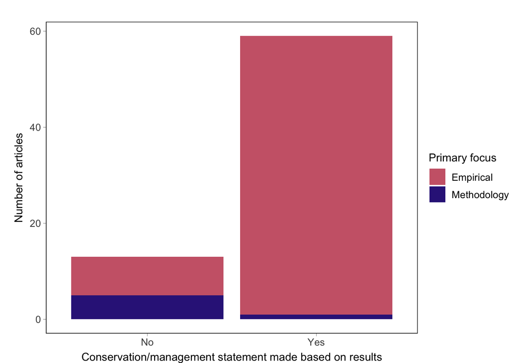

```r
cons_plot <- ggplot() +
  geom_bar(data = review, aes(x=as.factor(ManagementConservationInference),
                              fill = as.factor(PrimaryFocus))) +
  theme_classic() +
  xlab("Conservation/management statement made based on results") +
  ylab("Number of articles") +
  guides(fill = guide_legend(title="Primary focus")) +
  scale_fill_grafify(palette = "muted") +
  theme(axis.title = element_text(size = rel(1)),
        axis.text = element_text(size = rel(0.9)),
        axis.title.x = element_text(margin = margin(t = 5)),
        axis.title.y = element_text(margin = margin(r = 5)),
        legend.title = element_text(size = rel(1)),
        legend.text = element_text(size = rel(0.9)),
        legend.margin = margin(0, 0, 0, 0),
        panel.border = element_rect(colour = "black", fill=NA, linewidth = 0.5),
        axis.line = element_line(colour = 'black', linewidth = 0.1),
        axis.ticks = element_line(colour = 'black', linewidth = 0.1),
        plot.margin = unit(c(1.5, 0, 0, 1), 'lines'))
cons_plot
```

## Inclusion of individual characteristics

Let’s first look at fitness/health proxy.

```r
review %>% select(IncludeCharacteristicsOfFitnessHealthSpecific) %>% table()
```

```
## IncludeCharacteristicsOfFitnessHealthSpecific
##                               No No, but focus on calving habitat
##                               62                                2
##      No, but focus on kill sites        No, but survival analysis
##                                1                                4
##                              Yes
##                                3
```

Let’s change the value of `No, but survival analysis` to something more understandable.

```r
review <- review %>%
  mutate(IncludeCharacteristicsOfFitnessHealthSpecific =
           recode(IncludeCharacteristicsOfFitnessHealthSpecific,
                  "No, but survival analysis" = "No, but include survival analysis"))
review %>% select(IncludeCharacteristicsOfFitnessHealthSpecific) %>% table()
```

```
## IncludeCharacteristicsOfFitnessHealthSpecific
##                                No  No, but focus on calving habitat
##                                62                                 2
##       No, but focus on kill sites No, but include survival analysis
##                                 1                                 4
##                               Yes
##                                 3
```

```r
fit_yes <- review %>% filter(IncludeCharacteristicsOfFitnessHealthSpecific == "Yes") %>%
  select(FitnessHealthCharacteristic, MethodCharacteristic, CommentMethodCharacteristic)
nrow(fit_yes)/n
```

```
## [1] 0.04166667
```

```r
fit_yes
```

```
## # A tibble: 3 × 3
##   FitnessHealthCharacteristic MethodCharacteristic        CommentMethodCharact…¹
##   <chr>                       <chr>                       <chr>
## 1 Size                        Interaction term (similar … Body size is included…
## 2 Reproductive status         Two-step approach (separat… They apply individual…
## 3 Dominance                   Two-step approach (separat… They compare the sele…
## # ℹ abbreviated name: ¹CommentMethodCharacteristic
```

```r
review %>% filter(IncludeCharacteristicsOfFitnessHealth == "Yes, but") %>%
  select(FitnessHealthCharacteristic, MethodCharacteristic, CommentMethodCharacteristic)
```

```
## # A tibble: 7 × 3
##   FitnessHealthCharacteristic        MethodCharacteristic CommentMethodCharact…¹
##   <chr>                              <chr>                <chr>
## 1 Mortality (but in survival analys… Interaction (simila… Interaction (similar …
## 2 Calving (but not comparing, just … NA                   They used movement da…
## 3 Mortality (but this is more akin … Thinning process (S… It's a smart way to i…
## 4 Mortality (but in the survival an… No individual chara… Individual difference…
## 5 Calving (but not comparing, just … No individual chara… Age and survival of c…
## 6 Mortality/kill but more focussed … No individual chara… Kill RSF of cougar us…
## 7 Mortality (but in the survival an… No individual chara… They do a survival an…
## # ℹ abbreviated name: ¹CommentMethodCharacteristic
```

Now let’s look at the other individual characteristics included in habitat selection analyses.

```r
review %>% select(IncludeOtherCharacteristic) %>% table()
```

```
## IncludeOtherCharacteristic
##  No Yes
##  52  20
```

```r
other_yes <- review %>% filter(IncludeOtherCharacteristic == "Yes") %>%
  select(OtherCharacteristic, MethodCharacteristic, CommentMethodCharacteristic)
nrow(other_yes)/n
```

```
## [1] 0.2777778
```

```r
other_yes %>% select(OtherCharacteristic) %>% table()
```

```
## OtherCharacteristic
##                 Age Age, Residency, Sex            Age, Sex               Group
##                   1                   1                   1                   1
##    Group, Residency   Knowledge, social           Residency      Residency, Sex
##                   1                   1                   1                   2
##                 Sex
##                  11
```

```r
other_yes %>% select(MethodCharacteristic) %>% table()
```

```
## MethodCharacteristic
##                                                      Additional terms
##                                                                     1
## Interaction (similar to our method) + survival analysis for mortality
##                                                                     1
##                              Interaction term (similar to our method)
##                                                                     1
##                                                     Separate analyses
##                                                                    12
##                 Two-step approach (separate analyses + post hoc test)
##                                                                     4
##           Two-step approach (separate analysis + post hoc comparison)
##                                                                     1
```

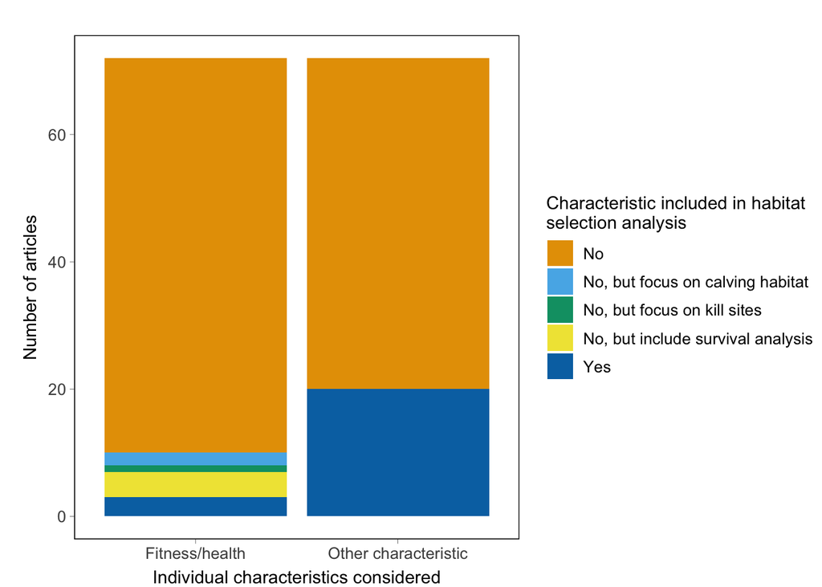

```r
char_plot <- ggplot() +
  geom_bar(data = review, aes(x = "1",
                              fill = as.factor(IncludeCharacteristicsOfFitnessHealthSpecific))) +
  geom_bar(data = review, aes(x = "2",
                              fill = as.factor(IncludeOtherCharacteristic))) +
  scale_x_discrete(breaks = c("1","2"),
        labels = c("Fitness/health", "Other characteristic")) +
  theme_classic() +
  xlab("Individual characteristics considered") +
  ylab("Number of articles") +
  guides(fill = guide_legend(title= "Characteristic included in habitat \nselection analysis")) +
  scale_fill_grafify() +
  theme(axis.title = element_text(size = rel(1)),
        axis.text = element_text(size = rel(0.9)),
        axis.title.x = element_text(margin = margin(t = 5)),
        axis.title.y = element_text(margin = margin(r = 5)),
        legend.title = element_text(size = rel(1)),
        legend.text = element_text(size = rel(0.9)),
        panel.border = element_rect(colour = "black", fill=NA, linewidth = 0.5),
        axis.line = element_line(colour = 'black', linewidth = 0.1),
        axis.ticks = element_line(colour = 'black', linewidth = 0.1),
        plot.margin = unit(c(1.5, 0, 0, 1), 'lines'))
char_plot
```

## Combined plots

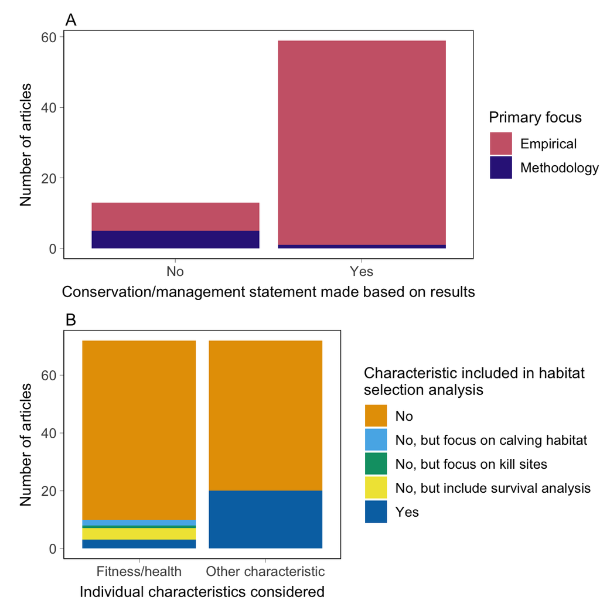

```r
ggarrange(cons_plot, char_plot,
          labels = c("A", "B"),
          label.x = rep(0.1, 2),
          label.y = rep(0.975, 2),
          font.label = list(size = 12, face="plain"),
          nrow = 2, ncol = 1)
```

# Literature cited

Matthiopoulos J., Fieberg J., Aarts G. , Beyer H. L. , Morales J. M. , Haydon D. T. (2015). Establishing the link between habitat selection and animal population dynamics. Ecol Monog 85, 413–436. https://doi.org/10.1890/14-2244.1